# Study 1B Confirmatory Analysis (2019-20) Output

## First factor: Subfield

```
## # A tibble: 4 × 2
##   subfield_groups     n
##   <chr>           <int>
## 1 Cognition          61
## 2 Development        34
## 3 Other              41
## 4 Social             57
```

## Second factor: Time

```
## # A tibble: 3 × 2
##   time_period       n
##   <chr>         <int>
## 1 1st half 2020    91
## 2 2nd half 2019    65
## 3 2nd half 2020    37
```

```
##  subfield_groups 1st half 2020 2nd half 2019 2nd half 2020
##        Cognition            29            19            13
##      Development            12            13             9
##            Other            17            17             7
##           Social            33            16             8
```

# DATA ANOVA Analysis

(#tab:unnamed-chunk-6)

*Between-subjects ANOVA for Open Data Scores*

| Effect | $F$ | $\mathit{df}_1$ | $\mathit{df}_2$ | $\mathit{MSE}$ | $p$ | $\hat{\eta}^2_G$ |
| --- | --- | --- | --- | --- | --- | --- |
| Time period | 3.68 | 2 | 181 | 70.92 | .027 | .039 |
| Subfield groups | 3.31 | 3 | 181 | 70.92 | .021 | .052 |
| Time period $\times$ Subfield groups | 1.11 | 6 | 181 | 70.92 | .358 | .035 |

Our two-way between-subjects ANOVA generated a significant main effect of time period, $F(2, 181) = 3.68$, $\mathit{MSE} = 70.92$, $p = .027$, $\hat{\eta}^2_G = .039$, and a significant main effect of subfield, $F(3, 181) = 3.31$, $\mathit{MSE} = 70.92$, $p = .021$, $\hat{\eta}^2_G = .052$. However, the interaction between time period and subfield, $F(6, 181) = 1.11$, $\mathit{MSE} = 70.92$, $p = .358$, $\hat{\eta}^2_G = .035$, was not statistically significant.

# MATERIALS ANOVA Analysis

```
## Contrasts set to contr.sum for the following variables: time_period, subfield_groups
```

(#tab:unnamed-chunk-7)

*Between-subjects ANOVA for Open Materials Scores*

| Effect | $F$ | $\mathit{df}_1$ | $\mathit{df}_2$ | $\mathit{MSE}$ | $p$ | $\hat{\eta}^2_G$ |
| --- | --- | --- | --- | --- | --- | --- |
| Time period | 0.37 | 2 | 181 | 53.87 | .694 | .004 |
| Subfield groups | 5.24 | 3 | 181 | 53.87 | .002 | .080 |
| Time period $\times$ Subfield groups | 0.48 | 6 | 181 | 53.87 | .822 | .016 |

Our two-way between-subjects ANOVA generated a significant main effect of subfield, $F(3, 181) = 5.24$, $\mathit{MSE} = 53.87$, $p = .002$, $\hat{\eta}^2_G = .080$, however the main effect of time period, $F(2, 181) = 0.37$, $\mathit{MSE} = 53.87$, $p = .694$, $\hat{\eta}^2_G = .004$, and the interaction between time period and subfield, $F(6, 181) = 0.48$, $\mathit{MSE} = 53.87$, $p = .822$, $\hat{\eta}^2_G = .016$, were not statistically significant.

# PLOTS

## DATA

### Subfield x Data Score

```
## # A tibble: 4 × 5
##   subfield_groups mean_data_score    SD     N stderr
##   <fct>                     <dbl> <dbl> <int>  <dbl>
## 1 Development                12.5  8.83    34  1.51
## 2 Social                     13.3  9.17    57  1.21
## 3 Cognition                  17.2  7.37    61  0.944
## 4 Other                      13.1  9.07    41  1.42
```

### Time Period x Data Score

```
## # A tibble: 3 × 5
##   time_period   mean_data_score    SD     N stderr
##   <fct>                   <dbl> <dbl> <int>  <dbl>
## 1 2nd half 2019            12.1  9.19    65  1.14
## 2 1st half 2020            16.0  8.08    91  0.847
## 3 2nd half 2020            14.4  8.70    37  1.43
```

### Interaction between time and subfield - Data scores

```
## # A tibble: 12 × 6
## # Groups:   subfield_groups [4]
##    subfield_groups time_period   mean_data_score    SD     N stderr
##    <fct>           <fct>                   <dbl> <dbl> <int>  <dbl>
##  1 Development     2nd half 2019            9.85  9.30    13   2.58
##  2 Development     1st half 2020           16.1   7.28    12   2.10
##  3 Development     2nd half 2020           11.6   9.33     9   3.11
##  4 Social          2nd half 2019            9.88  9.59    16   2.40
##  5 Social          1st half 2020           15.4   8.90    33   1.55
##  6 Social          2nd half 2020           11.6   7.93     8   2.80
##  7 Cognition       2nd half 2019           16.8   6.86    19   1.57
##  8 Cognition       1st half 2020           16.4   7.99    29   1.48
##  9 Cognition       2nd half 2020           19.6   6.63    13   1.84
## 10 Other           2nd half 2019           10.8   9.82    17   2.38
## 11 Other           1st half 2020           16.3   7.73    17   1.87
## 12 Other           2nd half 2020           11.3   9.16     7   3.46
```

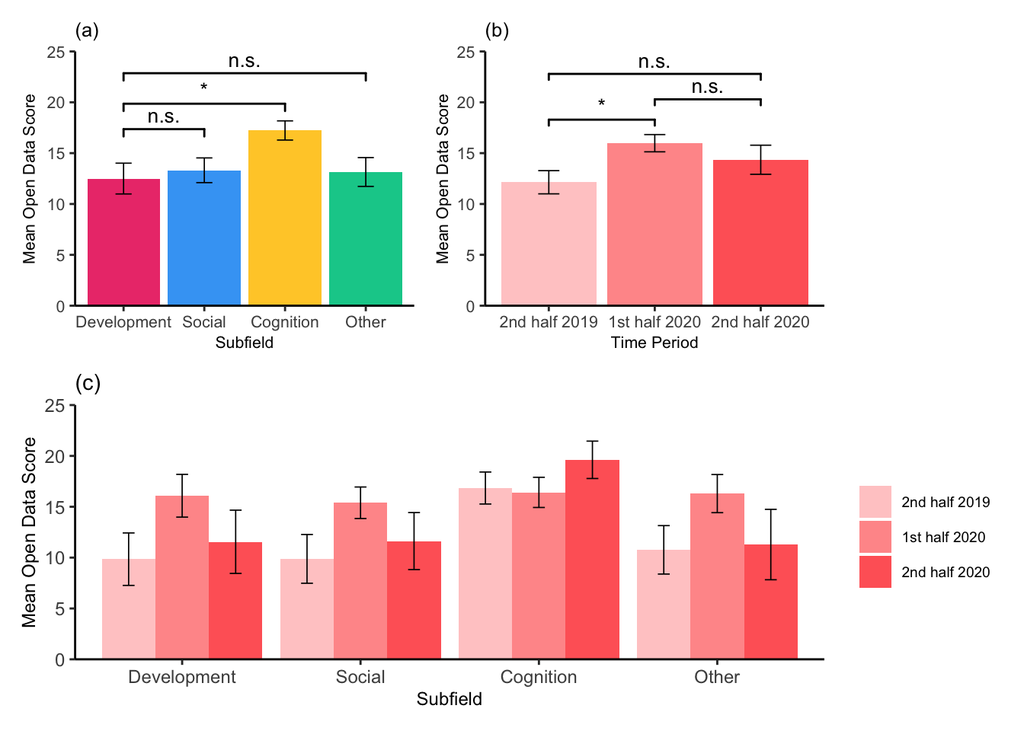

## MATERIALS

### Subfield x Materials Score

```
## # A tibble: 4 × 5
##   subfield_groups mean_materials_score    SD     N stderr
##   <fct>                          <dbl> <dbl> <int>  <dbl>
## 1 Development                     6.79  8.83    34  1.51
## 2 Social                          8.16  9.17    57  1.21
## 3 Cognition                      12.2   7.37    61  0.944
## 4 Other                           7.88  9.07    41  1.42
```

### Time Period x Materials Score

```
## # A tibble: 3 × 5
##   time_period   mean_materials_score    SD     N stderr
##   <fct>                        <dbl> <dbl> <int>  <dbl>
## 1 2nd half 2019                 8.35  7.53    65  0.934
## 2 1st half 2020                 9.54  7.31    91  0.766
## 3 2nd half 2020                 9.46  8.03    37  1.32
```

### Interaction between time and subfield - Materials Score

```
## # A tibble: 12 × 6
## # Groups:   subfield_groups [4]
##    subfield_groups time_period   mean_materials_score    SD     N stderr
##    <fct>           <fct>                        <dbl> <dbl> <int>  <dbl>
##  1 Development     2nd half 2019                 6.92  7.52    13   2.09
##  2 Development     1st half 2020                 6.33  7.62    12   2.20
##  3 Development     2nd half 2020                 7.22  8.47     9   2.82
##  4 Social          2nd half 2019                 6.69  7.58    16   1.89
##  5 Social          1st half 2020                 9.06  7.28    33   1.27
##  6 Social          2nd half 2020                 7.38  8.11     8   2.87
##  7 Cognition       2nd half 2019                12.3   6.50    19   1.49
##  8 Cognition       1st half 2020                11.4   6.92    29   1.28
##  9 Cognition       2nd half 2020                13.6   6.63    13   1.84
## 10 Other           2nd half 2019                 6.59  7.53    17   1.83
## 11 Other           1st half 2020                 9.53  7.49    17   1.82
## 12 Other           2nd half 2020                 7     8.29     7   3.13
```

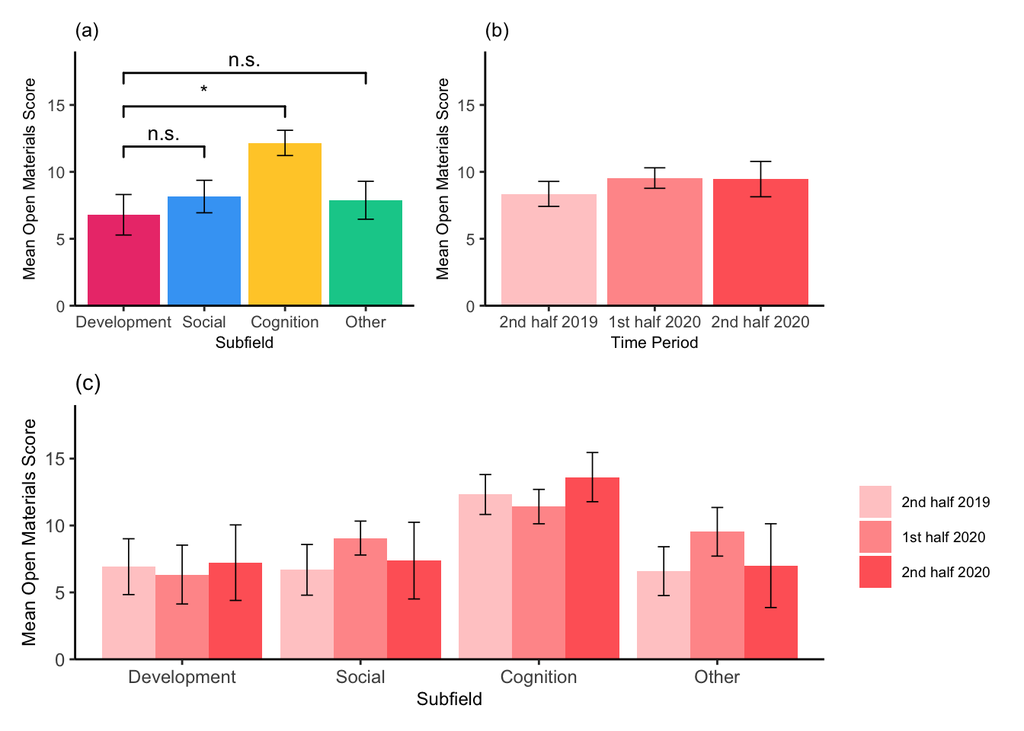

# SUBFIELD T-TESTS

## DATA

### Development vs. Cognition

```
## Effect sizes were labelled following Cohen's (1988) recommendations.
##
## The Welch Two Sample t-test testing the difference of open_data_score by subfield_groups (mean in group Development = 12.50, mean in group Cognition = 17.23) suggests that the effect is positive, statistically significant, and medium (difference = 4.73, 95% CI [-8.30, -1.16], t(58.75) = -2.65, p …
```

### Development vs. Social

```
## Effect sizes were labelled following Cohen's (1988) recommendations.
##
## The Welch Two Sample t-test testing the difference of open_data_score by subfield_groups (mean in group Development = 12.50, mean in group Social = 13.32) suggests that the effect is positive, statistically not significant, and very small (difference = 0.82, 95% CI [-4.68, 3.05], t(71.68) = -0.42…
```

### Development vs. Other

```
## Effect sizes were labelled following Cohen's (1988) recommendations.
##
## The Welch Two Sample t-test testing the difference of open_data_score by subfield_groups (mean in group Development = 12.50, mean in group Other = 13.15) suggests that the effect is positive, statistically not significant, and very small (difference = 0.65, 95% CI [-4.78, 3.49], t(71.12) = -0.31,…
```

## MATERIAL

### Developmental vs. Cognition

```
## Effect sizes were labelled following Cohen's (1988) recommendations.
##
## The Welch Two Sample t-test testing the difference of open_materials_score by subfield_groups (mean in group Development = 6.79, mean in group Cognition = 12.16) suggests that the effect is positive, statistically significant, and large (difference = 5.37, 95% CI [-8.48, -2.26], t(61.36) = -3.45,…
```

### Developmental vs. Social

```
## Effect sizes were labelled following Cohen's (1988) recommendations.
##
## The Welch Two Sample t-test testing the difference of open_materials_score by subfield_groups (mean in group Development = 6.79, mean in group Social = 8.16) suggests that the effect is positive, statistically not significant, and small (difference = 1.36, 95% CI [-4.62, 1.89], t(68.36) = -0.84, …
```

### Developmental vs. Other

```
## Effect sizes were labelled following Cohen's (1988) recommendations.
##
## The Welch Two Sample t-test testing the difference of open_materials_score by subfield_groups (mean in group Development = 6.79, mean in group Other = 7.88) suggests that the effect is positive, statistically not significant, and very small (difference = 1.08, 95% CI [-4.59, 2.42], t(70.45) = -0.…
```

# TIME T-TESTS

## DATA

### Second half 2019 vs. First half 2020

```
## Effect sizes were labelled following Cohen's (1988) recommendations.
##
## The Welch Two Sample t-test testing the difference of open_data_score by time_period (mean in group 2nd half 2019 = 12.14, mean in group 1st half 2020 = 15.98) suggests that the effect is positive, statistically significant, and small (difference = 3.84, 95% CI [-6.65, -1.03], t(126.73) = -2.70, …
```

### First half 2020 vs. Second half 2020

```
## Effect sizes were labelled following Cohen's (1988) recommendations.
##
## The Welch Two Sample t-test testing the difference of open_data_score by time_period (mean in group 1st half 2020 = 15.98, mean in group 2nd half 2020 = 14.35) suggests that the effect is negative, statistically not significant, and small (difference = -1.63, 95% CI [-1.69, 4.95], t(62.65) = 0.98…
```

### Second half 2019 vs. Second half 2020

```r
second2019_second2020 <- final1B %>%
  filter(time_period %in% c("2nd half 2019", "2nd half 2020"))

ttest9 <- t_test(open_data_score ~ time_period, second2019_second2020, paired = FALSE)

report(ttest9)
```

```
## Effect sizes were labelled following Cohen's (1988) recommendations.
##
## The Welch Two Sample t-test testing the difference of open_data_score by time_period (mean in group 2nd half 2019 = 12.14, mean in group 2nd half 2020 = 14.35) suggests that the effect is positive, statistically not significant, and small (difference = 2.21, 95% CI [-5.85, 1.43], t(78.51) = -1.21…
```

## MATERIALS

There time period main effect for Open Materials Scores was not statistically significant, so no t-tests to run here